# Calculations to get all data for all figures

Hanneke Leegwater

2024-03-15

# Introduction

This Rmd script reproduces all calculations performed for the manuscript “Normalization strategies for lipidome data in cell line panels”. We have created a small fake raw dataset that you can use for testing purposes if you want to use this code yourself. The real data cannot be published with this manuscript yet, but metabolomics data have been deposited to the EMBL-EBI MetaboLights database (DOI: 10.1093/nar/gkad1045, PMID:37971328) with the identifier MTBLS9493 and is accessible at https://www.ebi.ac.uk/metabolights/MTBLS9493.

# Preparations

## Load R libraries

```r
library(tidyverse)
library(here)
library(mixOmics)
library(limma)
library(ggvenn)
source(here("code/functions/normalize_lipidomics.R"))
source(here("code/functions/calculate_ICC_omics.R"))
```

```r
source(here("code/functions/data_analysis_plots.R"))
source(here("code/functions/calculate_lipid_class_average.R"))
source(here("code/functions/calculate_median_signal.R"))
```

## Define location of raw data

The raw data can be found in data. If you want to run this code yourself, change the file path to the test_dataset folder.

```r
data_dir <- here("data/normalization_manuscript_files")
#data_dir <- here("data/test_dataset")

str_glue("Using data from {data_dir}")
```

```
## Using data from C:/Users/leegwaterh/surfdrive/Manuscripts/2_the_lipidomics_normalization_story/code/data/normalization_manuscript_files
```

```r
stopifnot(dir.exists(data_dir))
```

## Create output directory

```r
output_dir <- here("manuscript/data_for_figures")
#output_dir <- here("data/normalization_manuscript_files")
if(!dir.exists(output_dir)) dir.create(output_dir, recursive = T)
```

## Open metadata

```r
# Sample metadata
metadata <- read_csv(here(data_dir, "metadata.csv"))
print(dim(metadata))
```

```
## [1] 213  13
```

```r
head(metadata)
```

| Original_name | group | cell_line | Treatment | Time | biological_replicate | batch_MSMS | Study | cell_nr_10E6 | corrected_conc_mg_per_mL | Morphology | Cellosaurus_RRID | Cellosaurus_Cell_line_name |
| --- | --- | --- | --- | --- | --- | --- | --- | --- | --- | --- | --- | --- |
| 1_MDA-MB-231 | MDA-MB-231 | MDA-MB-231 | NA | NA | 1 | 2 | Cell_line_panel | 7.13 | 0.4413697 | Mesenchymal-like | CVCL_0062 | MDA-MB-231 |
| 2_Hs578T | Hs578T | Hs578T | NA | NA | 1 | 2 | Cell_line_panel | 2.92 | 0.4408106 | Mesenchymal-like | CVCL_0332 | Hs 578T |
| 3_T47D | T47D | T47D | NA | NA | 1 | 3 | Cell_line_panel | 2.28 | 0.4037736 | Epithelial-like | CVCL_0553 | T-47D |
| 4_MCF-7 | MCF-7 | MCF-7 | NA | NA | 1 | 3 | Cell_line_panel | 4.87 | 0.7035639 | Epithelial-like | CVCL_0031 | MCF-7 |
| 5_SUM52PE | SUM52PE | SUM52PE | NA | NA | 1 | 3 | Cell_line_panel | 5.26 | 0.5793152 | Epithelial-like | CVCL_3425 | SUM52PE |
| 6_HCC38 | HCC38 | HCC38 | NA | NA | 1 | 3 | Cell_line_panel | 4.84 | 0.3611461 | Mesenchymal-like | CVCL_1267 | HCC38 |

```r
write_csv(metadata, here(output_dir, "metadata.csv"))

# Information on lipid classes
lipid_info <- read_csv(here(data_dir, "lipid_info.csv"))
print(dim(lipid_info))
```

```
## [1] 870  11
```

```r
head(lipid_info)
```

| internal_identifiers | identifiers | Abbreviation | Common Name | RSD_QC | measurement_mode | quality | Swiss Lipids | ISTD | class | subclass |
| --- | --- | --- | --- | --- | --- | --- | --- | --- | --- | --- |
| ANG_SM_d32.2 | SM d32:2 | SM(d32:2) | Sphingomyelin (d32:2) | 14.322035 | POS | Highlighted Metabolites | SLM:000390694 | ANG_SM_splash_d18.1_18.1_d9 | SM | SM |
| ANG_SM_d33.0 | SM d33:0 | SM(d33:0) | Sphingomyelin (d33:0) | 12.843715 | POS | Highlighted Metabolites | SLM:000390706 | ANG_SM_splash_d18.1_18.1_d9 | SM | SM |
| ANG_SM_d33.1 | SM d33:1 | SM(d33:1) | Sphingomyelin (d33:1) | 14.890874 | POS | Highlighted Metabolites | SLM:000390704 | ANG_SM_splash_d18.1_18.1_d9 | SM | SM |
| ANG_SM_d33.3 | SM d33:3 | SM(d33:3) | Sphingomyelin (d33:3) | 9.085934 | POS | Highlighted Metabolites | SLM:000390700 | ANG_SM_splash_d18.1_18.1_d9 | SM | SM |
| ANG_SM_d34.0 | SM d34:0 | SM(d34:0) | Sphingomyelin (d34:0) | 13.418295 | POS | Highlighted Metabolites | SLM:000390716 | ANG_SM_splash_d18.1_18.1_d9 | SM | SM |
| ANG_SM_d34.1 | SM d34:1 | SM(d34:1) | Sphingomyelin (d34:1) | 12.494674 | POS | Highlighted Metabolites | SLM:000390714 | ANG_SM_splash_d18.1_18.1_d9 | SM | SM |

```r
write_csv(lipid_info, here(output_dir, "lipid_info.csv"))
```

# Figure 1

Figure 1. Variation in data is mostly influenced by median signal in a sample.

## Calculate PCA for figure 1

PCA of samples and boxplot per morphology. Show that main patterns in data are not due to morphology or study, but overall signal before normalization. Data is log2 transformed before plotting and autoscaled in the PCA formula.

```r
log2_transform_data <- function(df){
  log2_data <- df %>%
    replace_missing_values_by_10percent() %>%
    log2transform_lipidomics() %>%
    column_to_rownames("Original_name")
  return(log2_data)
}

## Raw data from the studies
raw_data <- read_csv(here(data_dir, "raw_data.csv"))
dim(raw_data)
```

```
## [1] 150 871
```

```r
head(raw_data)
```

| Original_name | ANG_SM_d32.2 | ANG_SM_d33.0 | ANG_SM_d33.1 | ANG_SM_d33.3 | ANG_SM_d34.0 | ANG_SM_d34.1 | ANG_SM_d34.2 | ANG_SM_d34.3 | ANG_SM_d35.1 | ANG_SM_d35.2 | ANG_SM_d36.4 | ANG_SM_d37.4 | ANG_SM_d37.5 | ANG_SM_d39.0 | ANG_SM_d39.3 | ANG_SM_d40.4 | ANG_SM_d40.5 | ANG_SM_d40.7 | ANG_SM_d41.4 | ANG_SM_d42.0 | ANG_SM_d42.5 | ANG_SM_d42.6 | ANG_SM_d43.4 | ANG_SM_d44.0 | ANG_SM_d44.1 | ANG_SM_d44.4 | ANG_SM_d44.5 | ANG_GluCer14.0 | ANG_GluCerd18.0_24.0 | … |
| --- | --- | --- | --- | --- | --- | --- | --- | --- | --- | --- | --- | --- | --- | --- | --- | --- | --- | --- | --- | --- | --- | --- | --- | --- | --- | --- | --- | --- | --- | --- |
| 1_MDA-MB-231 | 0.026050817 | 0.09189810 | 1.0650796 | 0.36551166 | 3.3855542 | 1.1205423 | 2.7969901 | 0.48643990 | 0.52799418 | 3.3517998 | 0.06408847 | 0.5478446 | 0.2964708 | 1.8093492 | 0.20927153 | 0.38816986 | 0.10349574 | 1.8767736 | 0.51282472 | 0.44972953 | 0.8977650 | 0.24311748 | 0.41549636 | 0.0183290958 | 0.083235499 | 1.34412002 | 0.65057078 | 2.0257945 | 7.1973282 | … |
| 2_Hs578T | 0.003944867 | 0.02807443 | 0.2741332 | 0.13993763 | 1.5035433 | 0.4877933 | 0.3827282 | 0.07794608 | 0.19417502 | 0.7237305 | 0.04939760 | 0.5236740 | 0.2102842 | 0.2315136 | 0.04107602 | 0.06674498 | 0.01581445 | 0.2311623 | 0.11630314 | 0.11033795 | 0.2056489 | 0.03730647 | 0.15353963 | 0.0040586291 | 0.027334503 | 1.09330755 | 0.31256046 | 0.2920068 | 0.7428638 | … |
| 3_T47D | 0.040570800 | 0.08502889 | 0.8084518 | 0.63073628 | 2.7467799 | 1.4767164 | 1.6319943 | 0.14095797 | 0.27572794 | 1.0930660 | 0.03725970 | 0.5402704 | 0.3957808 | 1.9024868 | 0.07610961 | 0.24900886 | 0.12464504 | 1.4934828 | 0.19526567 | 0.57234610 | 0.7433676 | 0.56554815 | 0.18927168 | 0.0919847019 | 0.383273257 | 0.65993828 | 0.44334459 | 3.0430653 | 4.7278019 | … |
| 4_MCF-7 | 0.444223631 | 0.31058378 | 2.7703618 | 1.83883329 | 28.5407297 | 11.7275991 | 9.0020562 | 0.59830165 | 0.73092265 | 1.9812806 | 0.05707266 | 0.3216574 | 0.3148196 | 3.3688079 | 0.10670785 | 0.14676800 | 0.13140645 | 2.6200523 | 0.30324954 | 1.17158468 | 0.8654610 | 3.45460064 | 0.67793281 | 0.2797065095 | 1.305533104 | 1.42624553 | 1.16813282 | 3.8427722 | 3.5775411 | … |
| 5_SUM52PE | 0.042223773 | 0.22586548 | 2.6170220 | 0.78225702 | 7.7173678 | 2.7583988 | 3.2553034 | 0.32526715 | 0.73325320 | 2.2224739 | 0.07072898 | 0.5679634 | 0.3503959 | 4.0782488 | 0.54339892 | 0.53988598 | 0.18308651 | 4.0132095 | 1.02502597 | 1.09868079 | 1.2325835 | 1.10483812 | 1.31353417 | 0.1148852876 | 0.746859975 | 4.23712140 | 0.88277760 | 6.3755880 | 11.9702762 | … |
| 6_HCC38 | 0.002025343 | 0.01390303 | 0.1581079 | 0.04795315 | 0.4719114 | 0.2013772 | 0.2434310 | 0.03653422 | 0.06768187 | 0.2692416 | 0.02203663 | 0.2731607 | 0.1323390 | 0.1482612 | 0.03027759 | 0.02417153 | 0.01071813 | 0.1495443 | 0.04297527 | 0.02194897 | 0.0550639 | 0.04225126 | 0.03585233 | 0.0002410973 | 0.004278957 | 0.07725831 | 0.04175162 | 1.0959297 | 1.1286957 | … |

```r
raw_data_log2 <- log2_transform_data(raw_data)
```

```r
# Calculate PCA
dim(raw_data_log2)
```

```
## [1] 150 870
```

```r
dim(raw_data)
```

```
## [1] 150 871
```

```r
raw_data_log2_scaled <- scale(raw_data_log2, center = T, scale = T)
pca_raw_data <- mixOmics::pca(raw_data_log2_scaled, scale = F, ncomp =4)

# Save data frames and PCA results as R data objects
save(pca_raw_data, file = here(output_dir, "pca_raw_data.RData"))
write_csv(rownames_to_column(raw_data_log2, "Original_name"), here(output_dir, "raw_data_log2.csv"))
```

## Calculate median signal per sample

```r
medians_per_sample <- calculate_median_signal(raw_data, log2transform = T)

head(medians_per_sample)
```

|  | Original_name | median | log2median |
| --- | --- | --- | --- |
| 1 | 1_MDA-MB-231 | 0.16587521 | -2.5918298 |
| 2 | 2_Hs578T | 0.01006379 | -6.6346828 |
| 3 | 3_T47D | 0.16444371 | -2.6043343 |
| 4 | 4_MCF-7 | 0.25483071 | -1.9723890 |
| 5 | 5_SUM52PE | 0.52343933 | -0.9339058 |
| 6 | 6_HCC38 | 0.01162053 | -6.4271805 |

```r
# Add cell count and protein concentration
medians_per_sample <- medians_per_sample %>%
  left_join(dplyr::select(metadata, Original_name, cell_nr_10E6,
                          corrected_conc_mg_per_mL), by = "Original_name") %>%
  rename("prot conc. (mg/mL)" = corrected_conc_mg_per_mL,
         "cell count (million)" = cell_nr_10E6)

write_csv(medians_per_sample, here(output_dir, "medians_per_sample.csv"), na = "")
```

# Figure 2

Figure 2. Data-based normalizations improved similarity between biological replicates.

## Normalize data

Based on lab journal entry 1.4.2_Normalize_lipidomics_all_merged.Rmd

Calculation takes ~2 min.

```r
metadata_cell_lines <- metadata %>%
  filter(Study == "Cell_line_panel") %>%
  dplyr::select(Original_name, cell_nr_10E6, corrected_conc_mg_per_mL)
head(metadata_cell_lines)
```

| Original_name | cell_nr_10E6 | corrected_conc_mg_per_mL |
| --- | --- | --- |
| 1_MDA-MB-231 | 7.13 | 0.4413697 |
| 2_Hs578T | 2.92 | 0.4408106 |
| 3_T47D | 2.28 | 0.4037736 |
| 4_MCF-7 | 4.87 | 0.7035639 |
| 5_SUM52PE | 5.26 | 0.5793152 |
| 6_HCC38 | 4.84 | 0.3611461 |

```r
metadata_treatment_2DG_allreps <- metadata %>%
  filter(Study == "treatment_2DG") %>%
  dplyr::select(Original_name, cell_nr_10E6, corrected_conc_mg_per_mL, biological_replicate)

metadata_treatment_2DG <- metadata_treatment_2DG_allreps %>%
  filter(biological_replicate != 1) %>%
  dplyr::select(Original_name, cell_nr_10E6, corrected_conc_mg_per_mL)

head(metadata_treatment_2DG)
```

| Original_name | cell_nr_10E6 | corrected_conc_mg_per_mL |
| --- | --- | --- |
| 193_MDA-MB-231_ctrl-0 | 2.28 | 0.2964006 |
| 194_MDA-MB-231_ctrl-6 | 1.65 | 0.4693271 |
| 195_MDA-MB-231_ctrl-24 | 29.70 | 0.4179969 |
| 196_MDA-MB-231_ctrl-48 | 39.90 | 0.5801252 |
| 197_MDA-MB-231_2DG-6 | 1.60 | 0.3093897 |
| 198_MDA-MB-231_2DG-24 | 2.48 | 0.3289515 |

```r
raw_data_treatment_2DG_allreps <- read_csv(here(data_dir, "raw_data_treatment_2DG.csv"))
remove_rep1 <- function(df){
  df <- filter(df, Original_name %in% metadata_treatment_2DG$Original_name)
  return(df)
}
raw_data_treatment_2DG <- remove_rep1(raw_data_treatment_2DG_allreps)

# quick quality check
stopifnot(nrow(raw_data_treatment_2DG) == nrow(metadata_treatment_2DG))
stopifnot(nrow(raw_data) == nrow(metadata_cell_lines))
```

```r
data_cell_lines_list <- list()
data_treatment_2DG_list <- list()
output_normalizations <- here(output_dir, "data_normalized")

if(!dir.exists(output_normalizations)){
  dir.create(output_normalizations)
  dir.create(here(output_normalizations, "cell_lines"))
  dir.create(here(output_normalizations, "treatment_2DG"))
}
print(str_glue("Files saved to {output_normalizations}"))
```

```
## Files saved to C:/Users/leegwaterh/surfdrive/Manuscripts/2_the_lipidomics_normalization_story/code/manuscript/data_for_figures/data_normalized
```

```r
# Loop over all settings and all data frames
for(normalization_mode in c("pqn", "sum", "median", "not", "bca", "cellcount")){
for(data_subset in c("treatment_2DG", "cell_lines")){
  if(data_subset == "treatment_2DG"){
    df <- raw_data_treatment_2DG
    metadata_to_use <- metadata_treatment_2DG
  } else{
    df <- raw_data
    metadata_to_use <- metadata_cell_lines
  }
  print(str_glue("Processing {data_subset}, {normalization_mode}"))

  # Apply normalization
  if(normalization_mode == "not"){
    df <- df
    suffix <- str_glue("NotNormalized")
  } else if(normalization_mode == "bca"){
    df <- normalize_lipidomics(df, norm_values = metadata_to_use,
      column_to_use = "corrected_conc_mg_per_mL")
    suffix <- str_glue("BCANormalized")
  } else if(normalization_mode == "cellcount"){
    df <- normalize_lipidomics(df, norm_values = metadata_to_use,
            column_to_use = "cell_nr_10E6")
    suffix <- str_glue("CellCountNormalized")
  } else if(normalization_mode == "pqn"){
    df <- normalize_lipidomics_quotNorm(df)
    suffix <- str_glue("PQNNormalized")
  } else if(normalization_mode == "sum"){
    df <- normalize_lipidomics(df, "sum")
    suffix <- str_glue("SumNormalized")
  } else if(normalization_mode == "median"){
    df <- normalize_lipidomics(df, "median")
    suffix <- str_glue("MedianNormalized")
  }

  df_normalized <- df
  for(transformation in c("cuberootTransformed","log2Transformed", "notTransformed")){
  for(scaling in c("autoScaled","notScaled")){
  print(str_glue("Now calculating {transformation} {scaling}"))
  df <- df_normalized
  # Apply transformation and scaling
  if(transformation == "cuberootTransformed"){
    df <- cubeRootTransform_lipidomics(df)
  } else if(transformation == "log2Transformed"){
    df <- replace_missing_values_by_10percent(df)
    df <- log2transform_lipidomics(df)
  }

  # Apply scaling
  if(scaling == "paretoScaled"){
    df <- pareto_scale_lipids(df)
  } else if(scaling == "autoScaled"){
    df <- auto_scale_lipids(df)
  }

  suffix_to_use <- str_glue("{suffix}_{transformation}_{scaling}")
  # Store in list
  if(data_subset == "cell_lines"){
    data_cell_lines_list[[suffix_to_use]] <- df
  }else{
    data_treatment_2DG_list[[suffix_to_use]] <- df
  }

  # Save results
  save_normalized_df(df, output_normalizations, "merged", data_subset, suffix_to_use)
  }}
}}
```

```
## Processing treatment_2DG, pqn
## Now calculating cuberootTransformed autoScaled
## Saving as treatment_2DG_merged_PQNNormalized_cuberootTransformed_autoScaled.csv
## Now calculating cuberootTransformed notScaled
## Saving as treatment_2DG_merged_PQNNormalized_cuberootTransformed_notScaled.csv
## Now calculating log2Transformed autoScaled
## Saving as treatment_2DG_merged_PQNNormalized_log2Transformed_autoScaled.csv
## Now calculating log2Transformed notScaled
## Saving as treatment_2DG_merged_PQNNormalized_log2Transformed_notScaled.csv
## Now calculating notTransformed autoScaled
## Saving as treatment_2DG_merged_PQNNormalized_notTransformed_autoScaled.csv
## Now calculating notTransformed notScaled
## Saving as treatment_2DG_merged_PQNNormalized_notTransformed_notScaled.csv
## Processing cell_lines, pqn
## Now calculating cuberootTransformed autoScaled
## Saving as cell_lines_merged_PQNNormalized_cuberootTransformed_autoScaled.csv
## Now calculating cuberootTransformed notScaled
## Saving as cell_lines_merged_PQNNormalized_cuberootTransformed_notScaled.csv
## Now calculating log2Transformed autoScaled
## Saving as cell_lines_merged_PQNNormalized_log2Transformed_autoScaled.csv
## Now calculating log2Transformed notScaled
## Saving as cell_lines_merged_PQNNormalized_log2Transformed_notScaled.csv
## Now calculating notTransformed autoScaled
## Saving as cell_lines_merged_PQNNormalized_notTransformed_autoScaled.csv
## Now calculating notTransformed notScaled
## Saving as cell_lines_merged_PQNNormalized_notTransformed_notScaled.csv
## Processing treatment_2DG, sum
## [1] "Done with normalization"
## Now calculating cuberootTransformed autoScaled
## Saving as treatment_2DG_merged_SumNormalized_cuberootTransformed_autoScaled.csv
## Now calculating cuberootTransformed notScaled
## Saving as treatment_2DG_merged_SumNormalized_cuberootTransformed_notScaled.csv
## Now calculating log2Transformed autoScaled
## Saving as treatment_2DG_merged_SumNormalized_log2Transformed_autoScaled.csv
## Now calculating log2Transformed notScaled
## Saving as treatment_2DG_merged_SumNormalized_log2Transformed_notScaled.csv
## Now calculating notTransformed autoScaled
## Saving as treatment_2DG_merged_SumNormalized_notTransformed_autoScaled.csv
## Now calculating notTransformed notScaled
## Saving as treatment_2DG_merged_SumNormalized_notTransformed_notScaled.csv
```

[output cut: 109 more lines]

```
## Saving as treatment_2DG_merged_CellCountNormalized_notTransformed_notScaled.csv
## Processing cell_lines, cellcount
## [1] "Done with normalization"
## Now calculating cuberootTransformed autoScaled
## Saving as cell_lines_merged_CellCountNormalized_cuberootTransformed_autoScaled.csv
## Now calculating cuberootTransformed notScaled
## Saving as cell_lines_merged_CellCountNormalized_cuberootTransformed_notScaled.csv
## Now calculating log2Transformed autoScaled
## Saving as cell_lines_merged_CellCountNormalized_log2Transformed_autoScaled.csv
## Now calculating log2Transformed notScaled
## Saving as cell_lines_merged_CellCountNormalized_log2Transformed_notScaled.csv
## Now calculating notTransformed autoScaled
## Saving as cell_lines_merged_CellCountNormalized_notTransformed_autoScaled.csv
## Now calculating notTransformed notScaled
## Saving as cell_lines_merged_CellCountNormalized_notTransformed_notScaled.csv
```

## ICC part

This code calculates intraclass correlations for each lipid, after various normalization strategies.

## ICC calculations from list of raw and normalized data

Load lists of normalized data and calculate ICCs

```r
metadata_cell_lines <- metadata %>%
  filter(Study == "Cell_line_panel") %>%
  dplyr::select(Original_name, group, biological_replicate)
head(metadata_cell_lines)
```

| Original_name | group | biological_replicate |
| --- | --- | --- |
| 1_MDA-MB-231 | MDA-MB-231 | 1 |
| 2_Hs578T | Hs578T | 1 |
| 3_T47D | T47D | 1 |
| 4_MCF-7 | MCF-7 | 1 |
| 5_SUM52PE | SUM52PE | 1 |
| 6_HCC38 | HCC38 | 1 |

```r
metadata_treatment_2DG <- metadata %>%
  filter(Study == "treatment_2DG") %>%
  filter(biological_replicate != 1) %>%
  dplyr::select(Original_name, group, biological_replicate)
head(metadata_treatment_2DG)
```

| Original_name | group | biological_replicate |
| --- | --- | --- |
| 193_MDA-MB-231_ctrl-0 | MDA-MB-231_ctrl-0 | 2 |
| 194_MDA-MB-231_ctrl-6 | MDA-MB-231_ctrl-6 | 2 |
| 195_MDA-MB-231_ctrl-24 | MDA-MB-231_ctrl-24 | 2 |
| 196_MDA-MB-231_ctrl-48 | MDA-MB-231_ctrl-48 | 2 |
| 197_MDA-MB-231_2DG-6 | MDA-MB-231_2DG-6 | 2 |
| 198_MDA-MB-231_2DG-24 | MDA-MB-231_2DG-24 | 2 |

Lists of normalized datasets were created above, but can also be read from previous saved files if needed.

```r
lists_for_ICC <- c("PQNNormalized_log2Transformed_notScaled",
                   "SumNormalized_log2Transformed_notScaled",
                   "MedianNormalized_log2Transformed_notScaled",
                   "NotNormalized_log2Transformed_notScaled",
                   "BCANormalized_log2Transformed_notScaled",
                   "CellCountNormalized_log2Transformed_notScaled")
ICC_cell_lines_normalization_merged <- calculate_ICC_for_each_dataset(data_cell_lines_list[lists_for_ICC], metadata_cell_lines)
ICC_treatment_2DG_normalization_merged <- calculate_ICC_for_each_dataset(data_treatment_2DG_list[lists_for_ICC], metadata_treatment_2DG)
```

Some naming cleanup:

```r
rename_cols <- function(df){
  parts_to_remove <- c("cell_lines_|treatment_2DG_|POS_|NEG_|TG_|merged_|
                       |_log2Transformed|_notScaled|.csv|Normalized")
  df <- df %>%
  rename_with(function(x) str_remove_all(x, parts_to_remove)) %>%
  rename_with(function(x) str_replace(x, "BCA", "Prot conc.")) %>%
  rename_with(function(x) str_replace(x, "CellCount", "Cell count")) %>%
  rownames_to_column("lipid")
  return(df)
}

ICC_cell_lines_normalization_merged <- rename_cols(ICC_cell_lines_normalization_merged)
dim(ICC_cell_lines_normalization_merged)
```

```
## [1] 870   7
```

```r
colnames(ICC_cell_lines_normalization_merged)
```

```
## [1] "lipid"      "PQN"        "Sum"        "Median"     "Not"
## [6] "Prot conc." "Cell count"
```

```r
ICC_treatment_2DG_normalization_merged <- rename_cols(ICC_treatment_2DG_normalization_merged)
dim(ICC_treatment_2DG_normalization_merged)
```

```
## [1] 870   7
```

```r
colnames(ICC_treatment_2DG_normalization_merged)
```

```
## [1] "lipid"      "PQN"        "Sum"        "Median"     "Not"
## [6] "Prot conc." "Cell count"
```

```r
write_csv(ICC_cell_lines_normalization_merged, here(output_dir, "ICC_cell_lines_normalization_merged.csv"), na = "")

write_csv(ICC_treatment_2DG_normalization_merged, here(output_dir, "ICC_treatment_2DG_normalization_merged.csv"), na = "")
```

## Part with density distributions

No additional calculations are needed for this plot.

# Figure 3

Figure 3. Lipid abundance distributions are not directly related to total protein concentration or cell count.

Sample signal distributions related to protein concentration or cell count. In order to show 5 cell lines with similar and different median signals, I need to calculate the mean and sd of protein concentrations and cell count per cell line, the median and sd of signals per measurement mode (already done for fig 1).

### Mean and sd of biological measures per cell line

```r
sd_biological_measurements <- metadata %>%
  filter(Study == "Cell_line_panel") %>%
  dplyr::select(Original_name, group, corrected_conc_mg_per_mL, cell_nr_10E6) %>%
  group_by(group) %>%
  summarise(mean_protein_concentration_mg_per_mL = mean(corrected_conc_mg_per_mL),
            sd_protein_concentration_mg_per_mL = sd(corrected_conc_mg_per_mL),
            mean_cell_nr_10E6 = mean(cell_nr_10E6),
            sd_cell_nr_10E6 = sd(cell_nr_10E6))

## Check if it looks ok for one cell line
metadata %>%
  filter(cell_line == "T47D") %>%
  dplyr::select(Original_name, group, corrected_conc_mg_per_mL, cell_nr_10E6)
```

| Original_name | group | corrected_conc_mg_per_mL | cell_nr_10E6 |
| --- | --- | --- | --- |
| 3_T47D | T47D | 0.4037736 | 2.28 |
| 57_T47D | T47D | 0.3932817 | 5.86 |
| 112_T47D | T47D | 0.3788506 | 4.43 |

```r
sd_biological_measurements %>% filter(group == "T47D")
```

| group | mean_protein_concentration_mg_per_mL | sd_protein_concentration_mg_per_mL | mean_cell_nr_10E6 | sd_cell_nr_10E6 |
| --- | --- | --- | --- | --- |
| T47D | 0.3919686 | 0.01251328 | 4.19 | 1.802027 |

```r
write_csv(sd_biological_measurements, here(output_dir, "sd_biological_measurements.csv"))
```

# Figure 4

Figure 4 Correlation between class averages before normalization shows an overall agreement for structural lipids, but not for triglycerides and some signaling lipids.

Here, class averages and correlations are calculated.

```r
subclass_averages_transformed_scaled <- data_cell_lines_list[["NotNormalized_log2Transformed_autoScaled"]] %>%
  calculate_lipid_class_average(lipid_info, subclass = T)
dim(subclass_averages_transformed_scaled)
```

```
## [1] 3300    4
```

```r
head(subclass_averages_transformed_scaled)
```

| Original_name | subclass | subclass_mean | subclass_sd |
| --- | --- | --- | --- |
| 101_SUM190PT | CE | -0.4330175 | 0.5753464 |
| 101_SUM190PT | Cer | 0.3607124 | 0.6240046 |
| 101_SUM190PT | DG | 0.1497599 | 0.3063540 |
| 101_SUM190PT | HexCer | -0.7695362 | 0.7028424 |
| 101_SUM190PT | LPC | -0.4017280 | 0.4773099 |
| 101_SUM190PT | LPE | -0.7242536 | 0.4561007 |

```r
# Restructure dataframe
subclass_averages_transformed_scaled <- subclass_averages_transformed_scaled %>%
  dplyr::select(-subclass_sd) %>%
  pivot_wider(id_cols = Original_name, names_from = subclass, values_from = subclass_mean) %>%
  column_to_rownames("Original_name") %>%
  cor() %>%
  data.frame() %>%
  rownames_to_column("lipid_subclass")

dim(subclass_averages_transformed_scaled)
```

```
## [1] 22 23
```

```r
head(subclass_averages_transformed_scaled)
```

|  | lipid_subclass | CE | Cer | DG | HexCer | LPC | LPE | LPE.O | LPG | LPI | LPS | LacCer | PC | PE | PE.O | PE.P | PG_or_BMP | PI | PS | SM | TG | dhCer | unknown.sphingolipid |
| --- | --- | --- | --- | --- | --- | --- | --- | --- | --- | --- | --- | --- | --- | --- | --- | --- | --- | --- | --- | --- | --- | --- | --- |
| 1 | CE | 1.0000000 | 0.6364358 | 0.7414470 | 0.6126729 | 0.4976028 | 0.5168891 | 0.3896815 | 0.5631387 | 0.5177406 | 0.5133313 | 0.6059072 | 0.6129422 | 0.5218439 | 0.5904557 | 0.5374195 | 0.6041829 | 0.5260599 | 0.6915562 | 0.6473610 | 0.5547997 | 0.6959729 | 0.2172752 |
| 2 | Cer | 0.6364358 | 1.0000000 | 0.7417301 | 0.7289063 | 0.7093377 | 0.7121541 | 0.6917156 | 0.7361878 | 0.7942725 | 0.7205097 | 0.7132186 | 0.8036061 | 0.8202396 | 0.7698747 | 0.6275136 | 0.7786326 | 0.8266753 | 0.8299202 | 0.7120228 | 0.5532344 | 0.9094239 | 0.5933672 |
| 3 | DG | 0.7414470 | 0.7417301 | 1.0000000 | 0.5054937 | 0.7132244 | 0.6670659 | 0.6568324 | 0.6932293 | 0.7495767 | 0.6947099 | 0.5625357 | 0.8358344 | 0.8161634 | 0.7677169 | 0.6573314 | 0.7781036 | 0.7948926 | 0.8080519 | 0.6969846 | 0.8283833 | 0.7424786 | 0.6060442 |
| 4 | HexCer | 0.6126729 | 0.7289063 | 0.5054937 | 1.0000000 | 0.5072962 | 0.6015168 | 0.4985847 | 0.5892901 | 0.6170644 | 0.5692393 | 0.7912248 | 0.5637935 | 0.5704538 | 0.5861651 | 0.5107050 | 0.5908763 | 0.5786191 | 0.6827200 | 0.6072146 | 0.2771270 | 0.7533466 | 0.3377576 |
| 5 | LPC | 0.4976028 | 0.7093377 | 0.7132244 | 0.5072962 | 1.0000000 | 0.8588318 | 0.8212841 | 0.7681110 | 0.8592780 | 0.8432117 | 0.5766924 | 0.8567029 | 0.8327838 | 0.8263756 | 0.7328497 | 0.7594089 | 0.8827232 | 0.8258932 | 0.6954046 | 0.4529731 | 0.6941541 | 0.6960366 |
| 6 | LPE | 0.5168891 | 0.7121541 | 0.6670659 | 0.6015168 | 0.8588318 | 1.0000000 | 0.8733002 | 0.7140488 | 0.8393139 | 0.8223011 | 0.6675413 | 0.7532613 | 0.8040595 | 0.8941432 | 0.8798765 | 0.7667856 | 0.8480136 | 0.8054536 | 0.6787564 | 0.4635076 | 0.7133785 | 0.5675730 |

```r
write_csv(subclass_averages_transformed_scaled,
          here(output_dir, "class_average_correlations.csv"))
```

## Sum of structural lipids in raw data

```r
sums_of_structural_lipids <- raw_data %>%
      pivot_longer(!Original_name, names_to = "internal_identifiers", values_to = "value") %>%
      left_join(dplyr::select(lipid_info, internal_identifiers, class), by = "internal_identifiers") %>%
      filter(class %in% c("PI", "PE", "PC", "PS", "SM")) %>%
      group_by(Original_name) %>%
      summarise(structural_lipid_sum = sum(value)) %>%
      ungroup()

sums_of_TGs <- raw_data %>%
      pivot_longer(!Original_name, names_to = "internal_identifiers", values_to = "value") %>%
      left_join(dplyr::select(lipid_info, internal_identifiers, class), by = "internal_identifiers") %>%
      filter(class == "TG") %>%
      group_by(Original_name) %>%
      summarise(TG_sum = sum(value)) %>%
      ungroup()

sums_of_structural_lipids %>%
  inner_join(sums_of_TGs, by = "Original_name") %>%
  write_csv(here(output_dir, "rawdata_sums_of_structural_lipids_and_TGs.csv"))
```

# Figure 5

Figure 5 Differences in PE class average between morphologies are partially caused by normalization.

## Normalize by structural lipids

```r
structural_lipid_classes <- c("PE", "PS", "PI", "PC", "SM")
structural_lipids <- filter(lipid_info,
                           class %in% c("PE", "PS", "PI", "PC", "SM")) %>%
    pull(internal_identifiers)

data_cell_lines_list[["PQN_SLNormalized_notTransformed_notScaled"]] <-
  normalize_lipidomics_quotNorm_structural_lipids(raw_data, structural_lipids)
```

```
## Normalization will be based on 321 out of 870 lipids.
```

```r
data_cell_lines_list[["PQN_SLNormalized_log2Transformed_autoScaled"]] <-
  data_cell_lines_list[["PQN_SLNormalized_notTransformed_notScaled"]] %>%
    replace_missing_values_by_10percent() %>%
    log2transform_lipidomics() %>%
    auto_scale_lipids()

data_cell_lines_list[["PQN_SLNormalized_cuberootTransformed_autoScaled"]] <-
  data_cell_lines_list[["PQN_SLNormalized_notTransformed_notScaled"]] %>%
    cubeRootTransform_lipidomics() %>%
    auto_scale_lipids()
```

## Calculate class averages for TG and PE

```r
calculate_lipid_class_averages <- function(df){

  df_average <- df %>%
    pivot_longer(!Original_name, names_to = "internal_identifiers", values_to = "value") %>%
    left_join(dplyr::select(lipid_info, internal_identifiers, class), by = "internal_identifiers") %>%
    filter(class %in% c("TG", "PE")) %>%
    group_by(Original_name, class) %>%
    summarise(class_mean = mean(value),
              class_sd = sd(value)) %>%
    ungroup()

  print(dim(df_average))
  print(head(df_average))
  return(df_average)
}

class_averages_TGPE_rawdata <- data_cell_lines_list[["NotNormalized_log2Transformed_autoScaled"]] %>%
  calculate_lipid_class_averages()
```

```
## [1] 300   4
## # A tibble: 6 × 4
##   Original_name class class_mean class_sd
##   <chr>         <chr>      <dbl>    <dbl>
## 1 101_SUM190PT  PE       -0.423     0.376
## 2 101_SUM190PT  TG       -0.0264    0.364
## 3 103_SK-BR-5   PE        0.0821    0.471
## 4 103_SK-BR-5   TG        0.413     0.372
## 5 104_OCUB-F    PE        0.740     0.374
## 6 104_OCUB-F    TG        1.10      0.363
```

```r
class_averages_merged <- data_cell_lines_list[["PQNNormalized_log2Transformed_autoScaled"]] %>%
  calculate_lipid_class_averages()
```

```
## [1] 300   4
## # A tibble: 6 × 4
##   Original_name class class_mean class_sd
##   <chr>         <chr>      <dbl>    <dbl>
## 1 101_SUM190PT  PE        -0.324    0.602
## 2 101_SUM190PT  TG         0.242    0.564
## 3 103_SK-BR-5   PE        -0.271    0.726
## 4 103_SK-BR-5   TG         0.326    0.599
## 5 104_OCUB-F    PE        -0.343    0.564
## 6 104_OCUB-F    TG         0.758    0.626
```

```r
class_averages_by_structural_lipids <- data_cell_lines_list[["PQN_SLNormalized_log2Transformed_autoScaled"]] %>%
  calculate_lipid_class_averages()
```

```
## [1] 300   4
## # A tibble: 6 × 4
##   Original_name class class_mean class_sd
##   <chr>         <chr>      <dbl>    <dbl>
## 1 101_SUM190PT  PE       -0.0940    0.685
## 2 101_SUM190PT  TG        0.301     0.437
## 3 103_SK-BR-5   PE        0.124     0.877
## 4 103_SK-BR-5   TG        0.451     0.447
## 5 104_OCUB-F    PE        0.353     0.655
## 6 104_OCUB-F    TG        0.893     0.486
```

```r
## Correlate TG and PE quickly
calculate_TG_PE_cor <- function(df){
  TG_and_PE <- df %>%
    dplyr::select(-class_sd) %>%
    pivot_wider(id_cols = Original_name, names_from = class, values_from = class_mean)
  print(round(cor(TG_and_PE$PE, TG_and_PE$TG),3))
}

calculate_TG_PE_cor(class_averages_TGPE_rawdata)
```

```
## [1] 0.653
```

```r
calculate_TG_PE_cor(class_averages_merged)
```

```
## [1] -0.764
```

```r
calculate_TG_PE_cor(class_averages_by_structural_lipids)
```

```
## [1] 0.306
```

Write to file

```r
write_csv(class_averages_TGPE_rawdata, here(output_dir, "class_averages_TGPE_rawdata.csv"))
write_csv(class_averages_merged, here(output_dir, "class_averages_merged.csv"))
write_csv(class_averages_by_structural_lipids, here(output_dir, "class_averages_by_structural_lipids.csv"))
```

# Figure 6

Figure 6 Correlation of PCs after data transformation shows similar results.

## Average biological replicates

```r
average_biological_replicates <- function(df, metadata){
  metadata_to_use <- dplyr::select(metadata, Original_name, group)

  df <- left_join(df, metadata_to_use, df, by = "Original_name") %>%
    dplyr::select(-Original_name) %>%
    group_by(group) %>%
    summarise(across(everything(), function(x) mean(x, na.rm = TRUE)))
  return(df)
}
```

```r
data_cell_lines_list[["PQN_SLNormalized_log2Transformed_autoScaled"]] %>%
  average_biological_replicates(metadata = metadata) %>%
  write_csv(file = here(output_dir, "pqn_data_log2.csv"))


data_cell_lines_list[["PQN_SLNormalized_cuberootTransformed_autoScaled"]] %>%
  average_biological_replicates(metadata = metadata) %>%
  write_csv(file = here(output_dir, "pqn_data_cuberoot.csv"))
```

## Perform differential abundance analysis

```r
# Show epithelial and mesenchymal cell lines for report.
metadata %>%
  filter(Morphology == "Epithelial-like") %>% pull(group) %>% unique()
```

```
##  [1] "T47D"          "MCF-7"         "SUM52PE"       "HCC1954"
##  [5] "EVSA-T"        "HCC1419"       "SK-BR-3"       "BT20"
##  [9] "BT483"         "MDA-MB-330"    "SUM185PE"      "HCC1500"
## [13] "HCC202"        "UACC893"       "ZR75-30"       "MDA-MB-361"
## [17] "UACC812"       "MDA-MB-175VII" "MDA-MB-415"    "ZR75-1"
## [21] "HCC1569"       "SUM190PT"
```

```r
metadata %>%
  filter(Morphology == "Mesenchymal-like") %>% pull(group) %>% unique()
```

```
##  [1] "MDA-MB-231" "Hs578T"     "HCC38"      "HCC1806"    "SUM149PT"
##  [6] "SUM159PT"   "HCC1395"    "HCC1937"    "HCC70"      "HCC1143"
## [11] "SUM229PE"   "SUM102PT"   "SK-BR-7"    "SUM1315MO2" "BT549"
## [16] "MDA-MB-436" "HCC1187"
```

### Write function that calculates differential abundance

```r
### Specify design
design_df <- metadata %>% dplyr::select(group, Morphology) %>%
  filter(Morphology %in% c("Epithelial-like", "Mesenchymal-like")) %>%
  unique() %>%
  arrange("group") %>%
  column_to_rownames("group")
dim(design_df)
```

```
## [1] 39  1
```

```r
head(design_df)
```

|  | Morphology |
| --- | --- |
| MDA-MB-231 | Mesenchymal-like |
| Hs578T | Mesenchymal-like |
| T47D | Epithelial-like |
| MCF-7 | Epithelial-like |
| SUM52PE | Epithelial-like |
| HCC38 | Mesenchymal-like |

```r
design <- model.matrix(~Morphology, data = design_df)
design
```

```
##               (Intercept) MorphologyMesenchymal-like
## MDA-MB-231              1                          1
## Hs578T                  1                          1
## T47D                    1                          0
## MCF-7                   1                          0
## SUM52PE                 1                          0
## HCC38                   1                          1
## HCC1806                 1                          1
## SUM149PT                1                          1
## SUM159PT                1                          1
## HCC1395                 1                          1
## HCC1954                 1                          0
## HCC1937                 1                          1
## EVSA-T                  1                          0
## HCC1419                 1                          0
## SK-BR-3                 1                          0
## BT20                    1                          0
## HCC70                   1                          1
## HCC1143                 1                          1
## SUM229PE                1                          1
## SUM102PT                1                          1
## BT483                   1                          0
## MDA-MB-330              1                          0
## SK-BR-7                 1                          1
## SUM185PE                1                          0
## HCC1500                 1                          0
## HCC202                  1                          0
## UACC893                 1                          0
## ZR75-30                 1                          0
## MDA-MB-361              1                          0
## UACC812                 1                          0
## MDA-MB-175VII           1                          0
## MDA-MB-415              1                          0
## ZR75-1                  1                          0
## SUM1315MO2              1                          1
## BT549                   1                          1
## MDA-MB-436              1                          1
## HCC1569                 1                          0
## SUM190PT                1                          0
## HCC1187                 1                          1
## attr(,"assign")
## [1] 0 1
## attr(,"contrasts")
## attr(,"contrasts")$Morphology
## [1] "contr.treatment"
```

```r
differential_lipid_abundance <- function(df, design, return_all = F){
  # Filter to keep only previously specified cell lines and
  # Transpose to be ready for limma analysis
  df_t <- df %>%
    pivot_longer(!group, names_to = "lipid", values_to = "value") %>%
    pivot_wider(names_from = "group", values_from = "value") %>%
    column_to_rownames("lipid") %>%
    dplyr::select(all_of(rownames(design)))

  # Calculate differential lipids
  fit <- lmFit(df_t, design)
  fit <- eBayes(fit)

  result <- topTable(fit, coef = "MorphologyMesenchymal-like",
                     p.value = 0.1, number = ncol(df))

  if(!return_all){
    result <- topTable(fit, coef = "MorphologyMesenchymal-like",
                       p.value = 0.1, number = 10)
  }
  # Return results
  return(result)
}
```

### Apply to datasets

```r
data_cell_lines_list[["PQN_SLNormalized_log2Transformed_notScaled"]] <-
  data_cell_lines_list[["PQN_SLNormalized_notTransformed_notScaled"]]  %>%
            replace_missing_values_by_10percent() %>%
            log2transform_lipidomics()

data_cell_lines_list[["PQN_SLNormalized_cuberootTransformed_notScaled"]] <-
  data_cell_lines_list[["PQN_SLNormalized_notTransformed_notScaled"]]  %>%
            cubeRootTransform_lipidomics()


dataset_list <- list(
  "not" = data_cell_lines_list[["PQN_SLNormalized_notTransformed_notScaled"]] %>%
            average_biological_replicates(metadata = metadata),
  "cuberoot" = data_cell_lines_list[["PQN_SLNormalized_cuberootTransformed_notScaled"]] %>%
            average_biological_replicates(metadata = metadata),
  "log2" = data_cell_lines_list[["PQN_SLNormalized_log2Transformed_notScaled"]] %>%
            average_biological_replicates(metadata = metadata)
)
list_of_all_lipids <- list()

for(transformation in c("log2", "not", "cuberoot")){
  list_of_all_lipids[[transformation]] <- differential_lipid_abundance(
    dataset_list[[transformation]], design, return_all = T)

  # Print number of differential lipids
  print(str_c("Number of different lipids for ", transformation, " with p.adj<0.1 is: ",
    nrow(list_of_all_lipids[[transformation]])))
}
```

```
## [1] "Number of different lipids for log2 with p.adj<0.1 is: 345"
## [1] "Number of different lipids for not with p.adj<0.1 is: 49"
## [1] "Number of different lipids for cuberoot with p.adj<0.1 is: 278"
```

### Check and save lipids for the venn diagram

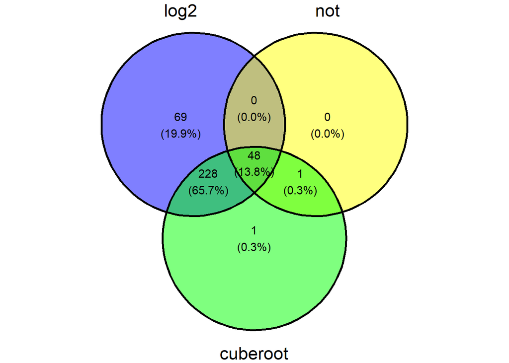

```r
ggvenn(lapply(list_of_all_lipids, rownames))
```

```r
venn_diagram_differential_lipids <- lapply(list_of_all_lipids, rownames)
save(venn_diagram_differential_lipids, file = here(output_dir, "venn_diagram_differential_lipids.RData"))
```

# Supplementary Figure 1

```r
metadata_cell_lines <- metadata %>%
  filter(Study == "Cell_line_panel") %>%
  dplyr::select(Original_name, group, biological_replicate)

lists_for_ICC <- data_cell_lines_list[c(
  "PQN_SLNormalized_notTransformed_notScaled",
  "PQN_SLNormalized_log2Transformed_notScaled",
  "PQN_SLNormalized_cuberootTransformed_notScaled"
)]

ICC_cell_lines_transformation <- calculate_ICC_for_each_dataset(lists_for_ICC, metadata_cell_lines) %>%
  rename_with(function(x) str_remove_all(x, "PQN_SLNormalized_|Transformed_notScaled"))
dim(ICC_cell_lines_transformation)
```

```
## [1] 870   3
```

```r
head(ICC_cell_lines_transformation)
```

|  | not | log2 | cuberoot |
| --- | --- | --- | --- |
| ANG_SM_d32.2 | 0.6897550 | 0.5854899 | 0.6703737 |
| ANG_SM_d33.0 | 0.8291615 | 0.7162362 | 0.7490463 |
| ANG_SM_d33.1 | 0.6017266 | 0.7017555 | 0.6353506 |
| ANG_SM_d33.3 | 0.6071098 | 0.6746081 | 0.6298328 |
| ANG_SM_d34.0 | 0.7901102 | 0.7897006 | 0.7955006 |
| ANG_SM_d34.1 | 0.4857940 | 0.6278348 | 0.5685612 |

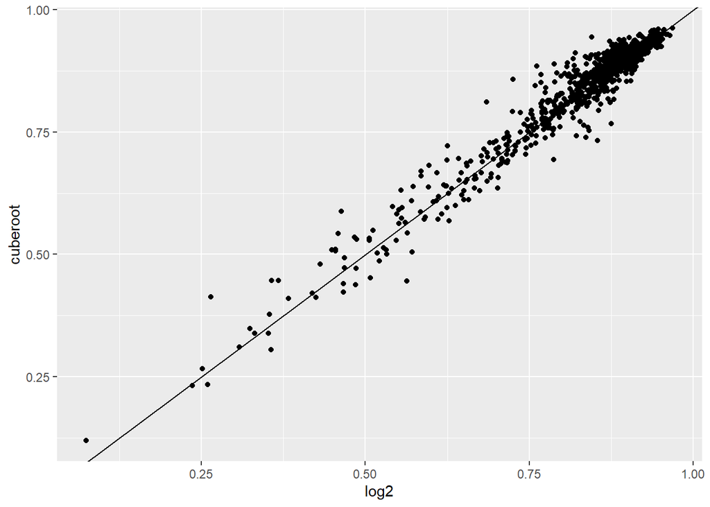

```r
ggplot(ICC_cell_lines_transformation, aes(x = log2, y = cuberoot)) + geom_point() + geom_abline(slope = 1)
```

```r
# temp <- ICC_cell_lines_transformation
write_csv(rownames_to_column(ICC_cell_lines_transformation, "lipid"), file = here(output_dir, "ICC_cell_lines_transformation.csv"))
```

# Supplementary Figure 2

Get all data for a single cell line BT549, all three replicates

```r
distributions_one_cell_line <- data_cell_lines_list[c(
  "NotNormalized_notTransformed_notScaled",
  "NotNormalized_log2Transformed_notScaled",
  "NotNormalized_cuberootTransformed_notScaled",
  "PQNNormalized_notTransformed_notScaled",
  "PQNNormalized_log2Transformed_notScaled",
  "PQNNormalized_cuberootTransformed_notScaled",
  "PQN_SLNormalized_notTransformed_notScaled",
  "PQN_SLNormalized_log2Transformed_notScaled",
  "PQN_SLNormalized_cuberootTransformed_notScaled")]

names(distributions_one_cell_line)
```

```
## [1] "NotNormalized_notTransformed_notScaled"
## [2] "NotNormalized_log2Transformed_notScaled"
## [3] "NotNormalized_cuberootTransformed_notScaled"
## [4] "PQNNormalized_notTransformed_notScaled"
## [5] "PQNNormalized_log2Transformed_notScaled"
## [6] "PQNNormalized_cuberootTransformed_notScaled"
## [7] "PQN_SLNormalized_notTransformed_notScaled"
## [8] "PQN_SLNormalized_log2Transformed_notScaled"
## [9] "PQN_SLNormalized_cuberootTransformed_notScaled"
```

```r
lapply(distributions_one_cell_line, dim)
```

```
## $NotNormalized_notTransformed_notScaled
## [1] 150 871
##
## $NotNormalized_log2Transformed_notScaled
## [1] 150 871
##
## $NotNormalized_cuberootTransformed_notScaled
## [1] 150 871
##
## $PQNNormalized_notTransformed_notScaled
## [1] 150 871
##
## $PQNNormalized_log2Transformed_notScaled
## [1] 150 871
##
## $PQNNormalized_cuberootTransformed_notScaled
## [1] 150 871
##
## $PQN_SLNormalized_notTransformed_notScaled
## [1] 150 871
##
## $PQN_SLNormalized_log2Transformed_notScaled
## [1] 150 871
##
## $PQN_SLNormalized_cuberootTransformed_notScaled
## [1] 150 871
```

```r
extract_one_cell_line <- function(normalization, transformation){
  # Filter the data frame
  df <- distributions_one_cell_line[[str_glue("{normalization}_{transformation}_notScaled")]] %>%
    filter(str_detect(Original_name, "BT549")) %>%
    mutate(normalization = normalization, transformation = transformation) %>%
    left_join(dplyr::select(metadata, Original_name, biological_replicate, group),
              by = "Original_name")

  print(dim(df))
  return(df)
}

reshuffle_columns_and_get_long_format <- function(df){
  df <- df %>%
    dplyr::select(-Original_name, -group) %>%
    pivot_longer(!c(biological_replicate, normalization, transformation),
                 names_to = "lipid", values_to = "value")
  return(df)
}
```

```r
BT549_density_info <- bind_rows(
  extract_one_cell_line("NotNormalized", "log2Transformed"),
  extract_one_cell_line("PQN_SLNormalized", "log2Transformed"),
  extract_one_cell_line("NotNormalized", "cuberootTransformed"),
  extract_one_cell_line("PQN_SLNormalized", "cuberootTransformed"),
  extract_one_cell_line("PQNNormalized", "log2Transformed"),
  extract_one_cell_line("PQNNormalized", "cuberootTransformed")
) %>%
  reshuffle_columns_and_get_long_format()
```

```
## [1]   3 875
## [1]   3 875
## [1]   3 875
## [1]   3 875
## [1]   3 875
## [1]   3 875
```

```r
head(BT549_density_info)
```

| normalization | transformation | biological_replicate | lipid | value |
| --- | --- | --- | --- | --- |
| NotNormalized | log2Transformed | 1 | ANG_SM_d32.2 | -4.2394013 |
| NotNormalized | log2Transformed | 1 | ANG_SM_d33.0 | -1.8121101 |
| NotNormalized | log2Transformed | 1 | ANG_SM_d33.1 | 0.6933313 |
| NotNormalized | log2Transformed | 1 | ANG_SM_d33.3 | -0.2282684 |
| NotNormalized | log2Transformed | 1 | ANG_SM_d34.0 | 3.7847492 |
| NotNormalized | log2Transformed | 1 | ANG_SM_d34.1 | 1.4235040 |

```r
write_csv(BT549_density_info, here(output_dir, "BT549_density_info.csv"), na = "")
```